# courseraModule8Assignment

kaka

25 December 2015

## Background

Using devices such as Jawbone Up, Nike FuelBand, and Fitbit it is now possible to collect a large amount of data about personal activity relatively inexpensively. These type of devices are part of the quantified self movement - a group of enthusiasts who take measurements about themselves regularly to improve their health, to find patterns in their behavior, or because they are tech geeks. One thing that people regularly do is quantify how much of a particular activity they do, but they rarely quantify how well they do it. In this project, your goal will be to use data from accelerometers on the belt, forearm, arm, and dumbell of 6 participants. They were asked to perform barbell lifts correctly and incorrectly in 5 different ways. More information is available from the website here: http://groupware.les.inf.puc-rio.br/har (see the section on the Weight Lifting Exercise Dataset).

## Data

The training data for this project are available here:

https://d396qusza40orc.cloudfront.net/predmachlearn/pml-training.csv

The test data are available here:

https://d396qusza40orc.cloudfront.net/predmachlearn/pml-testing.csv

The data for this project come from this source: http://groupware.les.inf.puc-rio.br/har.

## Methodology

Referring to principles of cross-validation, the below steps are taken :

## Setup data & library

```r
# setdefault global options for this document
if (!("knitr") %in% installed.packages()) install.packages("knitr")
library("knitr")
opts_chunk$set(echo=TRUE , warning=FALSE, message=FALSE )

# load library caret
if (!("e1071") %in% installed.packages())install.packages('e1071', dependencies = TRUE)
if (!("caret") %in% installed.packages())install.packages('caret', dependencies = TRUE)
if (!("rpart.plot") %in% installed.packages())install.packages('rpart.plot', dependencies = TRUE)

library(caret)
library(rpart)
library(rpart.plot)
library(randomForest)
# setwd
setwd("D:/#Coursera Material/R_workingDir/m8") ## Change this to your working directory

# download csv
if (!file.exists("pml-training.csv"))
download.file("https://d396qusza40orc.cloudfront.net/predmachlearn/pml-training.csv", destfile="./pml-training.csv")

if (!file.exists("pml-testing.csv"))
download.file("https://d396qusza40orc.cloudfront.net/predmachlearn/pml-testing.csv", destfile ="./pml-testing.csv")
```

## Set training/test sets

```r
trainSet <- read.csv(file = "./pml-training.csv" ,na.strings=c("NA",""))
testSet <- read.csv(file = "./pml-testing.csv" ,na.strings=c("NA",""))
```

## Data Processing

```r
dim(trainSet)
```

```
## [1] 19622   160
```

```r
#Train dataset has 160 columns . Let's filter them and only keep the useful columns by removing those NAs, non-numeric variable, near zero variable and variables that less important
trainSet <- trainSet[, which(colSums(is.na(trainSet))==0)] # rm NA

trainSet <- as.data.frame(trainSet[,-(1:7)])  # remove irrelevant columms

lastCol <- ncol(trainSet)
trainSet[,-lastCol] <- data.frame(sapply(trainSet[,-lastCol], as.numeric))
nzv <- nearZeroVar(trainSet[, -lastCol], saveMetrics=TRUE)
trainSet <- trainSet[nzv$nzv == FALSE]
dim(trainSet)
```

```
## [1] 19622    53
```

```r
trainSet$classe = factor(trainSet$classe)

# Manipulate testSet
dim(testSet)
```

```
## [1]  20 160
```

```r
testSet  <- testSet[, which(colSums(is.na(testSet))==0)] # rm NA
testSet <- as.data.frame(testSet[,-(1:7)])  # remove irrelevant columms
testSet <- testSet[nzv$nzv == FALSE]
dim(testSet)
```

```
## [1] 20 53
```

```r
# Creating partition for cross-validation
sample <- createDataPartition(trainSet$classe, p=0.75, list = FALSE)
subTrain <- trainSet[sample,]
subTest <- trainSet[-sample,]
```

## Predict Model 1: Decision Tree

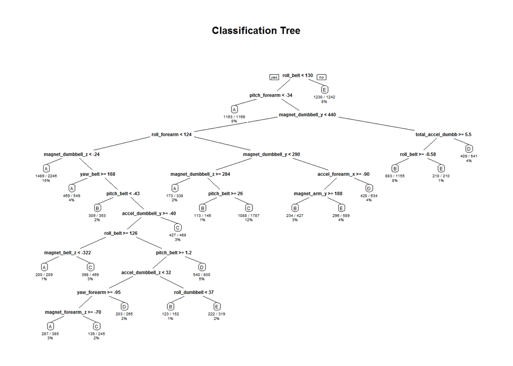

```r
model1 <- rpart(classe ~ ., data=subTrain, method="class")
prediction1 <- predict(model1, data=subTest, type = "class")
rpart.plot(model1, main="Classification Tree", extra=102, under=TRUE, faclen=0)
```

```r
confusionMatrix(prediction1, subTrain$classe)
```

```
## Confusion Matrix and Statistics
##
##           Reference
## Prediction    A    B    C    D    E
##          A 3781  612   75  274  154
##          B  104 1662  200   87  180
##          C   84  256 2052  322  275
##          D  147  195  179 1580  139
##          E   69  123   61  149 1958
##
## Overall Statistics
##
##                Accuracy : 0.7496
##                  95% CI : (0.7425, 0.7566)
##     No Information Rate : 0.2843
##     P-Value [Acc > NIR] : < 2.2e-16
##
##                   Kappa : 0.6815
##  Mcnemar's Test P-Value : < 2.2e-16
##
## Statistics by Class:
##
##                      Class: A Class: B Class: C Class: D Class: E
## Sensitivity            0.9035   0.5836   0.7994   0.6551   0.7236
## Specificity            0.8941   0.9519   0.9229   0.9464   0.9665
## Pos Pred Value         0.7723   0.7443   0.6865   0.7054   0.8297
## Neg Pred Value         0.9589   0.9050   0.9561   0.9333   0.9395
## Prevalence             0.2843   0.1935   0.1744   0.1639   0.1839
## Detection Rate         0.2569   0.1129   0.1394   0.1074   0.1330
## Detection Prevalence   0.3327   0.1517   0.2031   0.1522   0.1603
## Balanced Accuracy      0.8988   0.7677   0.8611   0.8007   0.8451
```

## Predict Model 2: Random Forest

```r
model2 <- randomForest(classe ~. , data=subTrain, method="class")
prediction2 <- predict(model2, subTest, type = "class")
confusionMatrix(prediction2, subTest$classe)
```

```
## Confusion Matrix and Statistics
##
##           Reference
## Prediction    A    B    C    D    E
##          A 1394    5    0    0    0
##          B    1  943    0    0    0
##          C    0    1  855    7    0
##          D    0    0    0  797    0
##          E    0    0    0    0  901
##
## Overall Statistics
##
##                Accuracy : 0.9971
##                  95% CI : (0.9952, 0.9984)
##     No Information Rate : 0.2845
##     P-Value [Acc > NIR] : < 2.2e-16
##
##                   Kappa : 0.9964
##  Mcnemar's Test P-Value : NA
##
## Statistics by Class:
##
##                      Class: A Class: B Class: C Class: D Class: E
## Sensitivity            0.9993   0.9937   1.0000   0.9913   1.0000
## Specificity            0.9986   0.9997   0.9980   1.0000   1.0000
## Pos Pred Value         0.9964   0.9989   0.9907   1.0000   1.0000
## Neg Pred Value         0.9997   0.9985   1.0000   0.9983   1.0000
## Prevalence             0.2845   0.1935   0.1743   0.1639   0.1837
## Detection Rate         0.2843   0.1923   0.1743   0.1625   0.1837
## Detection Prevalence   0.2853   0.1925   0.1760   0.1625   0.1837
## Balanced Accuracy      0.9989   0.9967   0.9990   0.9956   1.0000
```

## Model chosing

As we compare result above, Random Forest do has better accuracy. Hence, we would use model2 to predecit classe of testSet.

```r
finalPred <- predict(model2, testSet, type="class")
finalPred
```

```
##  1  2  3  4  5  6  7  8  9 10 11 12 13 14 15 16 17 18 19 20
##  B  A  B  A  A  E  D  B  A  A  B  C  B  A  E  E  A  B  B  B
## Levels: A B C D E
```

## Submission

```r
pml_write_files = function(x){
  n = length(x)
  for(i in 1:n){
    filename = paste0("problem_id_",i,".txt")
    write.table(x[i],file=filename,quote=FALSE,row.names=FALSE,col.names=FALSE)
  }
}

pml_write_files(finalPred)
```